# `selectFunctional`

### Grouped variable selection procedure for functional data

#### Description

Backward variable selection procedure for multivariate functional data which is a set of p functional covariates and n observations of dimension N.

#### Usage

```
selectFunctional( FDlist, ydata, normalize=TRUE,
dimensionReductionMethod=c("fpca", "wave"),
nbasisInit, verbose=TRUE, ...)
```

#### Arguments

- FDlist A p-dimensional list containing the set of functional variables which are matrices of size n x N.
- ydata The outcome data. Must be a factor for classification.
- normalize Should the functions be normalized ?
- dimensionReductionMethod: The dimension reduction method, âfpcaâ for Functional Principal Component Analysis or âwaveâ for the multiple wavelet thresholding.
- nbasisInit The number of initial spline coefficients.
- verbose Should the details be printed.
- … further arguments passed to or from other methods.

#### Examples

```r
data(toyRegFD)
varSel <- selectFunctional( toyRegFD$FDlist, toyRegFD$Y, normalize=FALSE,
dimensionReductionMethod="fpca", nbasisInit=16,
verbose=FALSE, ntree=10)
```

```r
summary(varSel)
```

```
##
##
##  ---                  ---
##  ---     Summary functional RFE   ---
##  ---                  ---
##
##
## Number of selected variables using a validation set: 15
##
## Selected variables:
## V1 V5 V2 V4 V3 V6 V9 V8 V15 V10 V17 V16 V20 V19 V12
##
## Validation error for the best model: 0.5823
```

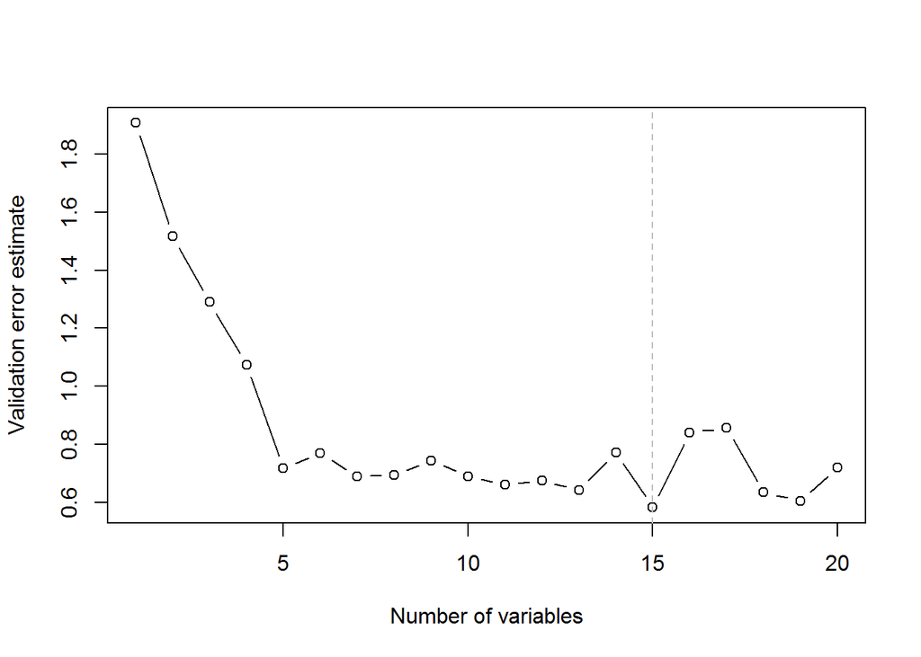

```r
plot(varSel)
```

#### Value An object of class fRFE which is a list with the following components: * nselected The number of selected functional variables ; * selection The selected functional variables ; * selectionIndexes The indexes of selected functional variables in the input data âFDlistâ ; * error The prediction error computed in each iteration of the backward procedure ; * typeRF The type of the forests, classification or regression ; * ranking The final ranking of the functional variables ; * rankingIndexes The final ranking indexes of the functional variables.

#### Author(s)

Baptiste Gregorutti

#### References

Gregorutti, B., Michel, B. and Saint Pierre, P. (2015). Grouped variable importance with random forests and application to multiple functional data analysis, Computational Statistics and Data Analysis 90, 15-35.

#### See Also

selectGroup,varImpGroup selectGroup 9